# STATS 201/8 Assignment 5

Kabir Patel Kpat913

Due Date: 3pm Thursday 12th October

# 1 Question 1

## 1.1 Questions of Interest

It was of interest to compare e-mail habits of adults, depending on their marital status.

## 1.2 Read in and inspect the data:

```r
email.df = read.csv("email.csv",stringsAsFactors = TRUE)
summary(email.df)
```

```
##      marital         email
##  divorced: 740   Min.   : 0.000
##  married :1867   1st Qu.: 0.000
##  never   :1362   Median : 2.000
##                  Mean   : 4.694
##                  3rd Qu.: 5.000
##                  Max.   :90.000
```

```r
with(email.df, table(email))
```

```
## email
##    0    1    2    3    4    5    6    7    8    9   10   11   12   13   14   15
## 1194  691  500  262  152  263   78  132   70    5  190    6   31    3   27   75
##   16   18   20   21   22   24   25   27   28   30   32   35   36   38   40   41
##    8    6   98    8    3    8   30    1    5   49    2    9    2    1   25    1
##   42   43   45   48   50   55   60   70   90
##    1    1    4    3   14    1    7    2    1
```

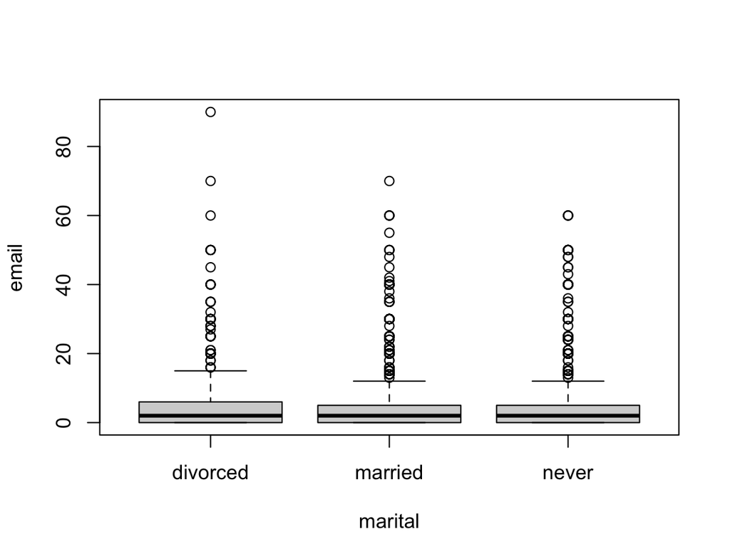

```r
plot(email~marital,data=email.df)
```

## 1.3 Comment on plot(s) and/or summary statistics

We can see here that the marital status of divorced had a count that was significantly less than the other two groups and that the never group had a count nearly twice the divorced group had. The married group also had a count more than twice what divorced had.

## 1.4 Fit and check model

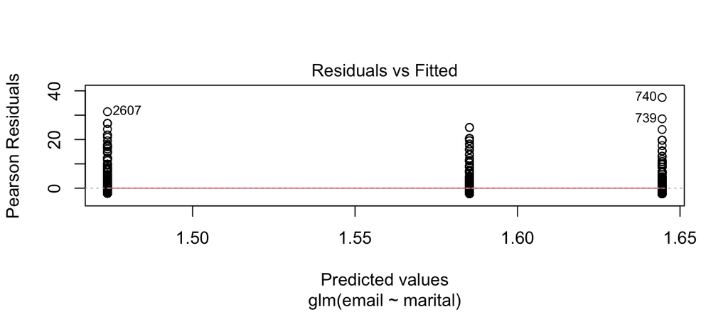

```r
Emailmarital.gfit = glm(email~marital, family = poisson, data=email.df)
plot(Emailmarital.gfit, which=1)
```

```r
summary(Emailmarital.gfit)
```

```
##
## Call:
## glm(formula = email ~ marital, family = poisson, data = email.df)
##
## Coefficients:
##                Estimate Std. Error z value Pr(>|z|)
## (Intercept)     1.64449    0.01615 101.799  < 2e-16 ***
## maritalmarried -0.17068    0.01959  -8.714  < 2e-16 ***
## maritalnever   -0.05928    0.02028  -2.923  0.00347 **
## ---
## Signif. codes:  0 '***' 0.001 '**' 0.01 '*' 0.05 '.' 0.1 ' ' 1
##
## (Dispersion parameter for poisson family taken to be 1)
##
##     Null deviance: 35726  on 3968  degrees of freedom
## Residual deviance: 35637  on 3966  degrees of freedom
## AIC: 44528
##
## Number of Fisher Scoring iterations: 6
```

```r
1 - pchisq(35637, 3966)
```

```
## [1] 0
```

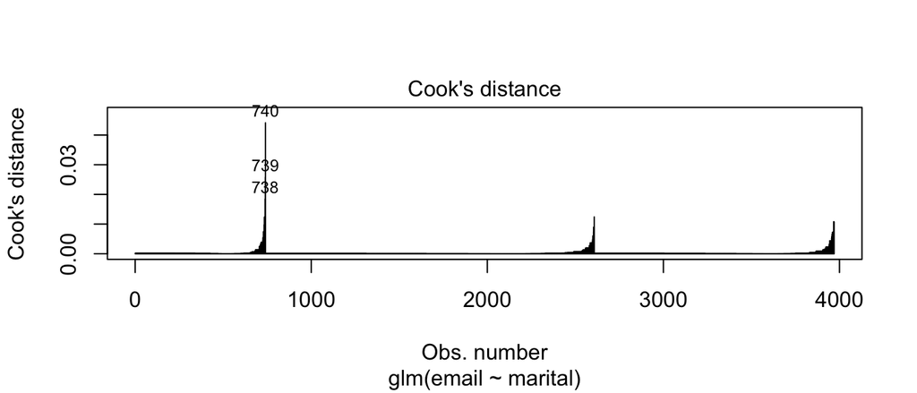

```r
Emailmarital.gfit2 = glm(email~marital, family = quasipoisson, data=email.df)
plot(Emailmarital.gfit2, which=4)
```

```r
summary(Emailmarital.gfit2)
```

```
##
## Call:
## glm(formula = email ~ marital, family = quasipoisson, data = email.df)
##
## Coefficients:
##                Estimate Std. Error t value Pr(>|t|)
## (Intercept)     1.64449    0.06093  26.988   <2e-16 ***
## maritalmarried -0.17068    0.07388  -2.310   0.0209 *
## maritalnever   -0.05928    0.07651  -0.775   0.4385
## ---
## Signif. codes:  0 '***' 0.001 '**' 0.01 '*' 0.05 '.' 0.1 ' ' 1
##
## (Dispersion parameter for quasipoisson family taken to be 14.22776)
##
##     Null deviance: 35726  on 3968  degrees of freedom
## Residual deviance: 35637  on 3966  degrees of freedom
## AIC: NA
##
## Number of Fisher Scoring iterations: 6
```

```r
exp(confint(Emailmarital.gfit2))
```

```
##                    2.5 %    97.5 %
## (Intercept)    4.5842934 5.8216590
## maritalmarried 0.7303055 0.9757474
## maritalnever   0.8119672 1.0960930
```

```r
email.df$marital = relevel(email.df$marital, ref="married")
emailmarital.gfit3 = glm(email~marital, family = quasipoisson, data = email.df)
exp(confint(emailmarital.gfit3))
```

```
##                     2.5 %   97.5 %
## (Intercept)     4.0180101 4.733144
## maritaldivorced 1.0248554 1.369290
## maritalnever    0.9889932 1.262847
```

```r
email.df$marital = relevel(email.df$marital, ref="never")
emailmarital.gfit4 = glm(email~marital, family = quasipoisson, data = email.df)
exp(confint(emailmarital.gfit4))
```

```
##                     2.5 %   97.5 %
## (Intercept)     4.4510480 5.336327
## maritalmarried  0.7918617 1.011129
## maritaldivorced 0.9123313 1.231577
```

```r
anova(Emailmarital.gfit2, test="F")
```

```
## Analysis of Deviance Table
##
## Model: quasipoisson, link: log
##
## Response: email
##
## Terms added sequentially (first to last)
##
##
##         Df Deviance Resid. Df Resid. Dev      F  Pr(>F)
## NULL                     3968      35726
## marital  2    89.59      3966      35637 3.1484 0.04303 *
## ---
## Signif. codes:  0 '***' 0.001 '**' 0.01 '*' 0.05 '.' 0.1 ' ' 1
```

## 1.5 Method and Assumption Checks

As the response variable, emails, is a count, we have fitted a generalized linear model with a quasipoisson response distribution. We have one explanatory variable with three factors, Married, Divorced, Never.

All assumptions were satisfied, there was evidence on the poisson model as the p-value was 0 which is lower then 0.05 so we can conclude that model was not adequate as there was overdispersion, thus using the quasipoisson model.

For our final model, we assume that the email count for observation is poisson with mean $u_i$ where

$log(u_i) = \beta_0 + \beta_1 \times maritalmarried_i + \beta_2 \times maritalnever_i$

and where $maritalmarried_i$ and $maritalnever_i$ are dummy variables which take the value 1 if observation is from $maritalnever_i$, otherwise they are 0.

We see that the marital status is significant as the Anova shows there is a difference between marital status because the p-value is lower than 0.05.

## 1.6 Executive Summary

We wanted to know if there was a difference in the number of emails sent by the 3 different marital groups, (married, divorced, never).

There is evidence of a difference in emails sent between the three groups, but the most significant difference is between married and divorced.

We estimate that on average the divorced group send between 2.48% and 36.93% higher than someone with in the married group.

# 2 Question 2

## 2.1 Questions of Interest

It was of interest to see how increasing APACHE II scores related to the mortality rate. In particular, to assess the effect of a 1 point or 5 point difference in APACHE II scores and to estimate mortality rates for APACHE II scores of 10, 20, 30 and 40.

### 2.1.1 Read in and inspect the data:

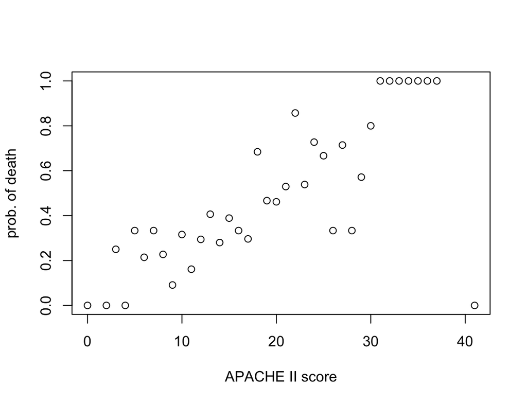

```r
Apache.df=read.csv("Apache.csv",header=TRUE)
plot(deaths/number_of_patients~apache_score,
     ylab="prob. of death",
     xlab="APACHE II score",data=Apache.df)
```

```r
head(Apache.df)
```

```
##   apache_score number_of_patients deaths
## 1            0                  1      0
## 2            2                  1      0
## 3            3                  4      1
## 4            4                 11      0
## 5            5                  9      3
## 6            6                 14      3
```

```r
tail(Apache.df,10)
```

```
##    apache_score number_of_patients deaths
## 29           29                  7      4
## 30           30                  5      4
## 31           31                  3      3
## 32           32                  3      3
## 33           33                  1      1
## 34           34                  1      1
## 35           35                  1      1
## 36           36                  1      1
## 37           37                  1      1
## 38           41                  1      0
```

## 2.2 Comment on plot

We see that as the Apache II score increases the prob. of death increases as well. Notable S curve.

## Fit and check model

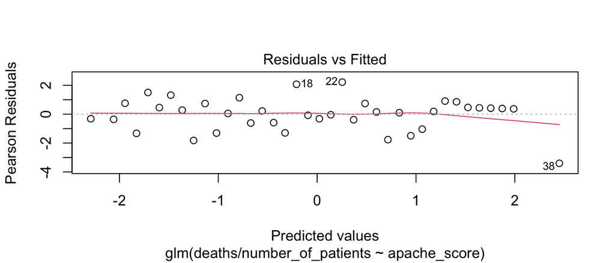

```r
Apache.fit=glm(deaths/number_of_patients~apache_score, family = binomial, data= Apache.df, weights = number_of_patients)
plot(Apache.fit, which = 1)
```

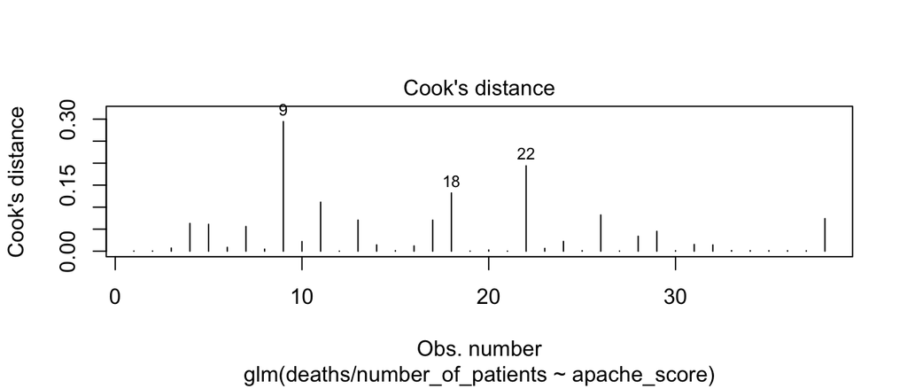

```r
plot(Apache.fit, which = 4)
```

```r
summary(Apache.fit)
```

```
##
## Call:
## glm(formula = deaths/number_of_patients ~ apache_score, family = binomial,
##     data = Apache.df, weights = number_of_patients)
##
## Coefficients:
##              Estimate Std. Error z value Pr(>|z|)
## (Intercept)   -2.2903     0.2765  -8.282  < 2e-16 ***
## apache_score   0.1156     0.0160   7.227 4.94e-13 ***
## ---
## Signif. codes:  0 '***' 0.001 '**' 0.01 '*' 0.05 '.' 0.1 ' ' 1
##
## (Dispersion parameter for binomial family taken to be 1)
##
##     Null deviance: 106.009  on 37  degrees of freedom
## Residual deviance:  43.999  on 36  degrees of freedom
## AIC: 125.87
##
## Number of Fisher Scoring iterations: 4
```

```r
1-pchisq(43.999, 36)
```

```
## [1] 0.169022
```

```r
exp(confint(Apache.fit))
```

```
##                  2.5 %    97.5 %
## (Intercept)  0.0579172 0.1715288
## apache_score 1.0888180 1.1594201
```

```r
exp(5*confint(Apache.fit))
```

```
##                     2.5 %       97.5 %
## (Intercept)  6.516853e-07 0.0001484858
## apache_score 1.530300e+00 2.0950968164
```

## 2.3 Get intervals to predict the probability of a patient admitted to ICU dying with 30 days with APACHE II scores of 10, 20, 30 or 40.

```r
predn=predictGLM(Apache.fit, data.frame(apache_score=c(10,20,30,40)), type="response")
```

```
## ***Estimates and CIs are on the response scale***
```

```r
predn
```

```
##         fit       lwr       upr
## 1 0.2434135 0.1960219 0.2980157
## 2 0.5055540 0.4462302 0.5647219
## 3 0.7646761 0.6672078 0.8404252
## 4 0.9117154 0.8257883 0.9574444
```

## 2.4 Method and Assumption Checks

The data recorded the number of patients and deaths where we then got the probability of death from deaths/number of patients. We then fitted a Binomial GLM with a single predictor of Alpache score (numeric).

There was no evidence of over dispersion as (p-Value = 0.169) so we can trust the results from this binomial model.

where prob (probability of death) is deaths/number of patients.

## 2.5 Write sentences, as if for an Executive Summary, interpret your four predictions intervals.

The probability of a patient admitted to ICU dying with 30 days with APACHE II score of 10 is between 0.196 and 0.298. This increases to between 0.446 and 0.565 for a score of 20, between 0.668 and 0.840 for a score of 30 and between 0.826 and 0.957 for a score of 40.

## 2.7 If we overlaid the model on the original plot, what shape would it be? (See question sheet for options.)

S-Shaped Curve